# Meta analyses of the IRAP’s reliability

Ian Hussey

25 January 2023

```r
set.seed(42)

# dependencies
library(tidyverse)
library(metafor)
library(knitr)
library(kableExtra)
library(psych)
library(ggExtra)
library(scales)
library(janitor)
library(parallel)
#library(ggtext) # devtools::install_github("clauswilke/ggtext")


# function to round all numeric vars in a data frame
round_df <- function(df, n_digits = 3) {
  df %>% mutate_if(is.numeric, janitor::round_half_up, digits = n_digits)
}

probability_of_superiority_function <- function(x, y) {
  nx <- length(x)
  ny <- length(y)
  rx <- sum(rank(c(x, y))[1:nx])
  A = (rx / nx - (nx + 1) / 2) / ny
  return(A)
}

spearman_brown_correction <- function(r_pearson) {
  inversion <- ifelse(r_pearson < 0, -1, 1)
  val <- janitor::round_half_up(2*abs(r_pearson)/(1 + abs(r_pearson)), 2)
  return(val*inversion)
}

apa_p_value <- function(p){
  p_formatted <- ifelse(p >= 0.001, paste("=", janitor::round_half_up(p, 3)),
                        ifelse(p < 0.001, "< .001", NA))
  p_formatted <- gsub(pattern = "0.", replacement = ".", x = p_formatted, fixed = TRUE)
  p_formatted
}

add_heterogeneity_metrics_to_forest <- function(fit) {
  bquote(paste("RE Model (", tau^2, " = ", .(formatC(janitor::round_half_up(fit$tau2, 2))),
               ", ", I^2, " = ", .(formatC(janitor::round_half_up(fit$I2, 1))),
               "%, ", H^2," = ", .(formatC(janitor::round_half_up(fit$H2, 2))), ")"))
}

# table format in output
options(knitr.table.format = "html")

# create directory needed to save output
dir.create("models")
dir.create("plots")
```

# Data

```r
data_demographics <-
  read_csv("../data/effect sizes for meta-analyses/data_demographics.csv")

data_D_scores_internal_consistency_oddeventrials <-
  read_csv("../data/effect sizes for meta-analyses/data_D_scores_internal_consistency_oddeventrials.csv")

data_D_scores_internal_consistency_firstsecondhalves <-
  read_csv("../data/effect sizes for meta-analyses/data_D_scores_internal_consistency_firstsecondhalves.csv")

data_D_scores_internal_consistency_permuted_estimates <-
  read_csv("../data/effect sizes for meta-analyses/data_D_scores_internal_consistency_permuted_estimates.csv")

data_A_scores_internal_consistency_permuted_estimates <-
  read_csv("../data/effect sizes for meta-analyses/data_A_scores_internal_consistency_permuted_estimates.csv")

data_D_scores_internal_consistency_permuted_estimates_by_block_order <-
  read_csv("../data/effect sizes for meta-analyses/data_D_scores_internal_consistency_permuted_estimates_by_block_order.csv")

data_D_scores_test_retest_r <-
  read_csv("../data/effect sizes for meta-analyses/data_D_scores_test_retest_r.csv")

data_D_scores_test_retest_icc <-
  read_csv("../data/effect sizes for meta-analyses/data_D_scores_test_retest_icc.csv")

# using stricter exclusion criteria
data_D_scores_internal_consistency_permuted_estimates_stricter <-
  read_csv("../data/effect sizes for meta-analyses/data_D_scores_internal_consistency_permuted_estimates_stricter.csv")

data_D_scores_test_retest_icc_stricter <-
  read_csv("../data/effect sizes for meta-analyses/data_D_scores_test_retest_icc_stricter.csv")
```

# Demographics

```r
data_demographics %>%
  summarize(mean_age = mean(age, na.rm = TRUE),
            sd_age = sd(age, na.rm = TRUE)) %>%
  round_df(1) %>%
  kable() %>%
  kable_styling(bootstrap_options = c("striped", "hover", "condensed"), full_width = FALSE)
```

| mean_age | sd_age |
| --- | --- |
| 19.9 | 3.8 |

```r
data_demographics %>%
  count(tolower(gender)) %>%
  arrange(desc(n)) %>%
  kable() %>%
  kable_styling(bootstrap_options = c("striped", "hover", "condensed"), full_width = FALSE)
```

| tolower(gender) | n |
| --- | --- |
| female | 824 |
| male | 517 |
| other | 3 |

```r
data_demographics %>%
  count(race) %>%
  arrange(desc(n)) %>%
  drop_na() %>%
  kable() %>%
  kable_styling(bootstrap_options = c("striped", "hover", "condensed"), full_width = FALSE)
```

| race | n |
| --- | --- |
| white | 315 |
| black | 202 |
| hispanic/latino | 62 |
| asian | 19 |
| multiracial | 10 |
| Other | 10 |
| american indian/alaska native | 3 |
| arabic | 1 |
| asian, black, white | 1 |
| hispanic and african-american | 1 |
| multi | 1 |
| multi-racial | 1 |
| native hawaiian/other pacific islander | 1 |
| saudi | 1 |
| saudi arabia | 1 |
| white and hispanic | 1 |

```r
data_demographics %>%
  count(sexuality) %>%
  drop_na() %>%
  arrange(desc(n)) %>%
  kable() %>%
  kable_styling(bootstrap_options = c("striped", "hover", "condensed"), full_width = FALSE)
```

| sexuality | n |
| --- | --- |
| heterosexual | 524 |
| bisexual | 46 |
| homosexual | 23 |

# Sample sizes

```r
data_D_scores_internal_consistency_permuted_estimates %>%
  summarize(total_ic_n = sum(n)) %>%
  kable() %>%
  kable_styling(bootstrap_options = c("striped", "hover", "condensed"), full_width = FALSE)
```

| total_ic_n |
| --- |
| 1688 |

```r
data_D_scores_test_retest_icc %>%
  summarize(total_trt_n = sum(n)) %>%
  kable() %>%
  kable_styling(bootstrap_options = c("striped", "hover", "condensed"), full_width = FALSE)
```

| total_trt_n |
| --- |
| 318 |

# Internal consistency

Three methods of calculating internal consistency for the Implicit Relational Assessment Procedure (IRAP): - Odd vs even trials (mostly commonly reported in literature) - First vs second half of task (more common for the most popular implicit measure, the IAT; would allow a like-for-like comparison) - Cronbach’s alpha via permutation (most robust)

The IRAP effect is most often quantified using the D1 scoring algorithm (Greenwald, Banaji & Nosek, 2003). i.e., trim all RTs > 10,000 ms, then D1 = (mean RT in the inconsistent blocks - mean RT in the consistent blocks)/SD of RTs in both block types. D1 scores are used throughout. Because of this, it wasn’t possible to use Sam Parson’s splithalf R package. A workflow for permutation-based alpha estimation using D scores is provided below.

In each case, correlations between D scores calculated from the split halves are calculated, and then the Spearman-Brown prophecy formula is applied, i.e., r_sb = 2*r_pearson / (1+r_pearson). Importantly, this correction is applied to the absolute value of the pearson’s correlation, and then its sign is corrected to be congruent with the pearson’s correlation. This ensures that r_sb has a possible range of -1 to +1, as correlations should (whereas correction of native negative correlations allow for a lower limit of -Inf). I haven’t seen this treatment of SB corrections applied to negative correlations well explicated elsewhere, so it is important to note here.

For meta analysis, spearman brown correlations are converted to Fischers r-to-z for meta analysis. Estimates of the meta effect are then converted back for reporting. Heterogeneity metrics represent heterogeneity in Fischer’s r-to-z estimates. See [here](https://stats.stackexchange.com/questions/26485/does-transformation-of-r-into-fisher-z-benefit-a-meta-analysis).

## Split-half reliability via odd vs. even trials

Bonett transformations

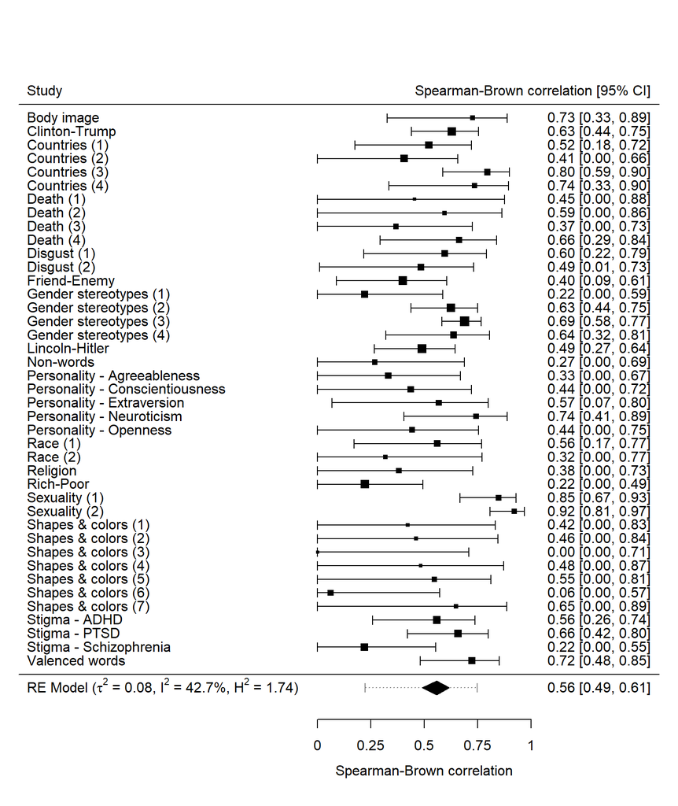

```r
# fit random Effects model
fit_oddeven <-  data_D_scores_internal_consistency_oddeventrials %>%
  rma(yi   = yi,
      vi   = vi,
      data = .,
      slab = domain)

# make predictions
predictions_oddeven <-
  predict(fit_oddeven, digits = 5) %>%
  as.data.frame() %>%
  round_df(2)

# plot
metafor::forest(fit_oddeven,
                xlab = "Spearman-Brown correlation",
                addcred = TRUE,
                refline = FALSE,
                transf = transf.iabt,
                xlim = c(-1.4, 1.6),
                at = c(0, 0.25, 0.5, 0.75, 1),
                mlab = add_heterogeneity_metrics_to_forest(fit_oddeven))
text(-1.4, 43, "Study", pos = 4)
text(1.6, 43, "Spearman-Brown correlation [95% CI]", pos = 2)
```

```r
# summarize results
meta_effect <-
  paste0("Meta analysis: k = ", fit_oddeven$k,
         ", r_sb = ",  janitor::round_half_up(transf.iabt(predictions_oddeven$pred), 2),
         ", 95% CI [", janitor::round_half_up(transf.iabt(predictions_oddeven$ci.lb), 2), ", ",
         janitor::round_half_up(transf.iabt(predictions_oddeven$ci.ub), 2), "]",
         ", 95% CR [", janitor::round_half_up(transf.iabt(predictions_oddeven$pi.lb), 2), ", ",
         janitor::round_half_up(transf.iabt(predictions_oddeven$pi.ub), 2), "]")

meta_heterogeneity <-
  paste0("Heterogeneity tests: Q(df = ", fit_oddeven$k - 1, ") = ", janitor::round_half_up(fit_oddeven$QE, 2),
         ", p ", ifelse(fit_oddeven$QEp < 0.0001, "< .0001", paste0("= ", as.character(janitor::round_half_up(fit_oddeven$QEp, 4)))),
         ", tau^2 = ", janitor::round_half_up(fit_oddeven$tau2, 2),
         ", I^2 = ",   janitor::round_half_up(fit_oddeven$I2, 2),
         "%, H^2 = ",   janitor::round_half_up(fit_oddeven$H2, 2))
```

Meta effect: Meta analysis: k = 41, r_sb = 0.56, 95% CI [0.49, 0.61], 95% CR [0.22, 0.75].

Heterogeneity: Heterogeneity tests: Q(df = 40) = 69.93, p = 0.0024, tau^2 = 0.08, I^2 = 42.65%, H^2 = 1.74.

## Split-half reliability via first vs. second half of the task

Bonett transformations

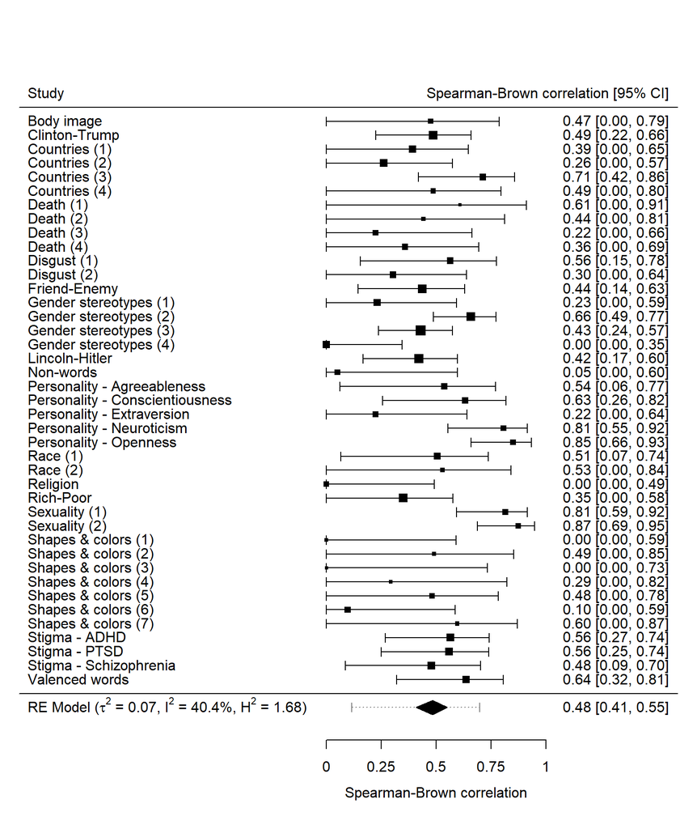

```r
# fit random Effects model
fit_firstsecond <- data_D_scores_internal_consistency_firstsecondhalves %>%
  rma(yi   = yi,
      vi   = vi,
      data = .,
      slab = domain)

# make predictions
predictions_firstsecond <-
  predict(fit_firstsecond, digits = 5) %>%
  as.data.frame() %>%
  round_df(2)

# plot
metafor::forest(fit_firstsecond,
                xlab = "Spearman-Brown correlation",
                addcred = TRUE,
                refline = FALSE,
                transf = transf.iabt,
                xlim = c(-1.4, 1.6),
                at = c(0, 0.25, 0.5, 0.75, 1),
                mlab = add_heterogeneity_metrics_to_forest(fit_firstsecond))
text(-1.4, 43, "Study", pos = 4)
text(1.6, 43, "Spearman-Brown correlation [95% CI]", pos = 2)
```

```r
# summarize results
meta_effect <-
  paste0("Meta analysis: k = ", fit_firstsecond$k,
         ", r_sb = ",  janitor::round_half_up(transf.iabt(predictions_firstsecond$pred), 2),
         ", 95% CI [", janitor::round_half_up(transf.iabt(predictions_firstsecond$ci.lb), 2), ", ",
         janitor::round_half_up(transf.iabt(predictions_firstsecond$ci.ub), 2), "]",
         ", 95% CR [", janitor::round_half_up(transf.iabt(predictions_firstsecond$pi.lb), 2), ", ",
         janitor::round_half_up(transf.iabt(predictions_firstsecond$pi.ub), 2), "]")

meta_heterogeneity <-
  paste0("Heterogeneity tests: Q(df = ", fit_firstsecond$k - 1, ") = ", janitor::round_half_up(fit_firstsecond$QE, 2),
         ", p ", ifelse(fit_firstsecond$QEp < 0.0001, "< .0001", paste0("= ", as.character(janitor::round_half_up(fit_firstsecond$QEp, 4)))),
         ", tau^2 = ", janitor::round_half_up(fit_firstsecond$tau2, 2),
         ", I^2 = ",   janitor::round_half_up(fit_firstsecond$I2, 2),
         "%, H^2 = ",   janitor::round_half_up(fit_firstsecond$H2, 2))
```

Meta effect: Meta analysis: k = 41, r_sb = 0.48, 95% CI [0.41, 0.55], 95% CR [0.11, 0.7].

Heterogeneity: Heterogeneity tests: Q(df = 40) = 67.71, p = 0.004, tau^2 = 0.07, I^2 = 40.44%, H^2 = 1.68.

## Permutation-based split half correlations

ie an estimate of alpha through large number number of random half splits (see Parsons, Kruijt, & Fox. 2019). Estimate of alpha obtained via mean of the resampled Spearman-Brown corrected split half correlations, when calculating D1 scores for each half and sampling 10000 permutations.

Plot native untransformed data.

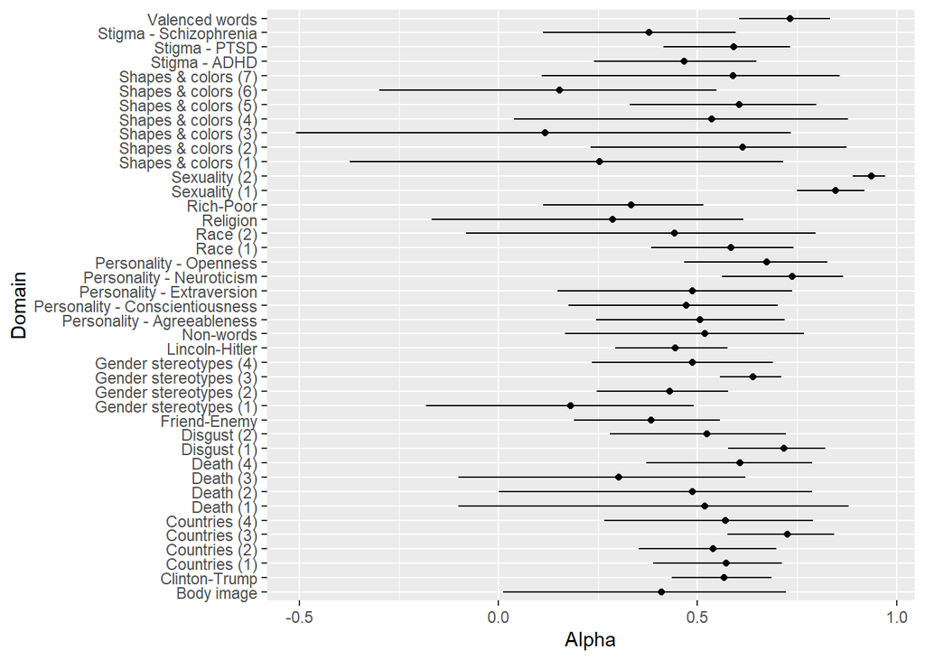

```r
ggplot(data_D_scores_internal_consistency_permuted_estimates,
       aes(y = alpha, x = domain)) +
  geom_linerange(aes(ymin = alpha_ci_lower, ymax = alpha_ci_upper)) +
  geom_point() +
  coord_flip() +
  xlab("Domain") +
  ylab("Alpha")
```

Bonett transformations

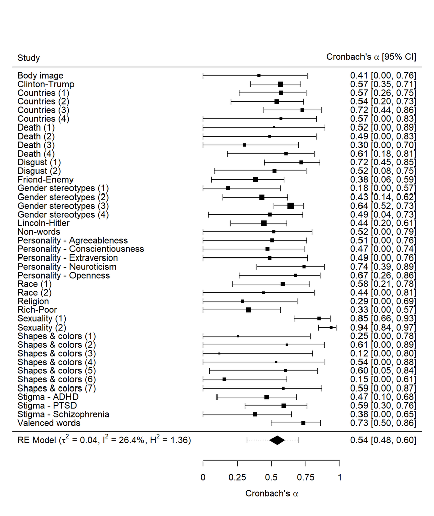

```r
# fit random Effects model
fit_internal_consistency_permuted_estimates <-
  data_D_scores_internal_consistency_permuted_estimates %>%
  rma(yi   = yi,
      vi   = vi,
      data = .,
      slab = domain)

# make predictions
predictions_permutations <-
  predict(fit_internal_consistency_permuted_estimates, digits = 5) %>%
  as.data.frame() %>%
  round_df(2)

# plot
metafor::forest(fit_internal_consistency_permuted_estimates,
                xlab = bquote(paste("Cronbach's ", alpha)),
                addcred = TRUE,
                refline = FALSE,
                transf = transf.iabt,
                xlim = c(-1.4, 1.6),
                at = c(0, 0.25, 0.5, 0.75, 1),
                mlab = add_heterogeneity_metrics_to_forest(fit_internal_consistency_permuted_estimates))
text(-1.4, 43, "Study", pos = 4)
text(1.6, 43, bquote(paste("Cronbach's ", alpha, " [95% CI]")), pos = 2)
```

```r
# summarize results
meta_effect <-
  paste0("Meta analysis: k = ", fit_internal_consistency_permuted_estimates$k,
         ", alpha = ",  janitor::round_half_up(transf.iabt(predictions_permutations$pred), 2),
         ", 95% CI [", janitor::round_half_up(transf.iabt(predictions_permutations$ci.lb), 2), ", ",
         janitor::round_half_up(transf.iabt(predictions_permutations$ci.ub), 2), "]",
         ", 95% CR [", janitor::round_half_up(transf.iabt(predictions_permutations$pi.lb), 2), ", ",
         janitor::round_half_up(transf.iabt(predictions_permutations$pi.ub), 2), "]")

meta_heterogeneity <-
  paste0("Heterogeneity tests: Q(df = ", fit_internal_consistency_permuted_estimates$k - 1, ") = ", janitor::round_half_up(fit_internal_consistency_permuted_estimates$QE, 2),
         ", p ", ifelse(fit_internal_consistency_permuted_estimates$QEp < 0.0001, "< .0001", paste0("= ", as.character(janitor::round_half_up(fit_internal_consistency_permuted_estimates$QEp, 4)))),
         ", tau^2 = ", janitor::round_half_up(fit_internal_consistency_permuted_estimates$tau2, 2),
         ", I^2 = ",   janitor::round_half_up(fit_internal_consistency_permuted_estimates$I2, 2),
         "%, H^2 = ",   janitor::round_half_up(fit_internal_consistency_permuted_estimates$H2, 2))

# save to disk for making pdf plot
write_rds(fit_internal_consistency_permuted_estimates, "models/fit_internal_consistency_permuted_estimates.rds")
```

Meta effect: Meta analysis: k = 41, alpha = 0.54, 95% CI [0.48, 0.6], 95% CR [0.32, 0.69].

Heterogeneity: Heterogeneity tests: Q(df = 40) = 56.98, p = 0.0398, tau^2 = 0.04, I^2 = 26.45%, H^2 = 1.36.

### GOSH

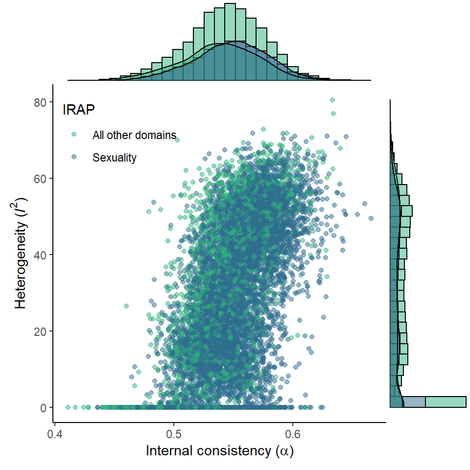

```r
if(!file.exists("models/fit_gosh_ic.rds")){

  fit_gosh_ic <- gosh(fit_internal_consistency_permuted_estimates,
                      subsets = 10000,
                      parallel = "multicore",  # change to "snow" on windows
                      ncpus = parallel::detectCores())

  write_rds(fit_gosh_ic, "models/fit_gosh_ic.rds")

} else {

  fit_gosh_ic <- read_rds("models/fit_gosh_ic.rds")

}

data_for_plotting_ic <-
  bind_cols(as.tibble(fit_gosh_ic$incl) %>%
              # the study to be separated is here listed by order (counting down from top of forest plot)
              select(include1 = "23",
                     include2 = "24"),
            as.tibble(fit_gosh_ic$res)) %>%
  mutate(IRAP = ifelse(include1 | include2, "Sexuality", "All other domains"),
         alpha = transf.iabt(estimate)) %>%
  # randomize rows to improve plotting
  sample_frac(size = 1)

p1 <-
  ggplot(data_for_plotting_ic, aes(alpha, I2, color = IRAP)) +
  geom_point(alpha = 0.5) +
  scale_color_viridis_d(begin = 0.35, end = 0.65, direction = -1) +
  theme_classic() +
  xlab(expression("Internal consistency (" * alpha * ")")) +
  ylab(expression("Heterogeneity (" * italic("I")^"2" * ")")) +
  theme(legend.position = c(0.2, 0.85),
        legend.background = element_rect(fill = scales::alpha("white", 0)))

plot_gosh_ic <-
  ggMarginal(p1,
             type = "densigram",
             size = 4,
             margins = "both",
             groupFill = TRUE)

plot_gosh_ic
```

```r
write_rds(plot_gosh_ic, "models/plot_gosh_ic.rds")

data_for_plotting_ic %>%
  group_by(IRAP) %>%
  summarize(alpha_median = median(alpha, na.rm = TRUE),
            alpha_ci_lower = quantile(alpha, 0.025, na.rm = TRUE),
            alpha_ci_upper = quantile(alpha, 0.975, na.rm = TRUE),
            I2_median = median(I2, na.rm = TRUE),
            I2_ci_lower = quantile(I2, 0.025, na.rm = TRUE),
            I2_ci_upper = quantile(I2, 0.975, na.rm = TRUE),
            H2_median = median(H2, na.rm = TRUE),
            H2_ci_lower = quantile(H2, 0.025, na.rm = TRUE),
            H2_ci_upper = quantile(H2, 0.975, na.rm = TRUE)) %>%
  round_df(2) %>%
  kable() %>%
  kable_styling(bootstrap_options = c("striped", "hover", "condensed"), full_width = FALSE)
```

| IRAP | alpha_median | alpha_ci_lower | alpha_ci_upper | I2_median | I2_ci_lower | I2_ci_upper | H2_median | H2_ci_lower | H2_ci_upper |
| --- | --- | --- | --- | --- | --- | --- | --- | --- | --- |
| All other domains | 0.54 | 0.47 | 0.60 | 29.37 | 0 | 63.51 | 1.42 | 1 | 2.74 |
| Sexuality | 0.55 | 0.48 | 0.61 | 27.69 | 0 | 60.71 | 1.38 | 1 | 2.54 |

### Sensitivity analysis

excluding Sexuality IRAPs as outliers

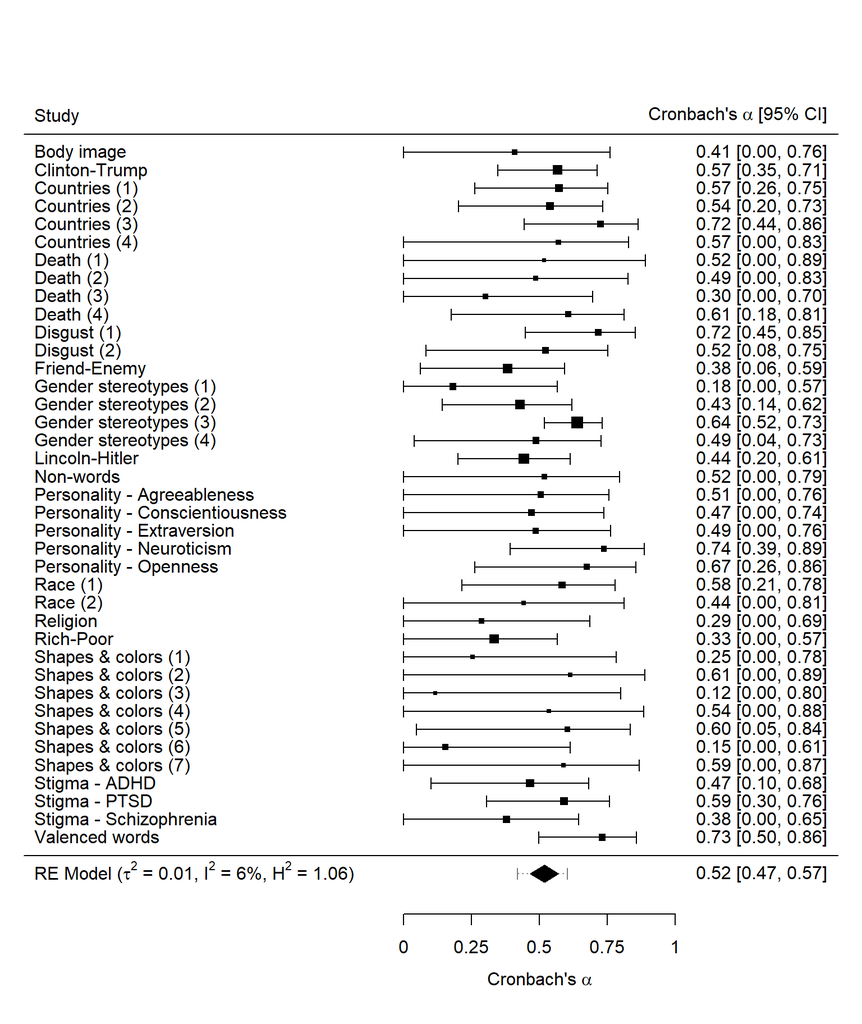

```r
# fit random Effects model
fit_internal_consistency_permuted_estimates_sensitivity <-
  data_D_scores_internal_consistency_permuted_estimates %>%
  filter(!str_detect(domain, "Sexuality")) %>%
  rma(yi   = yi,
      vi   = vi,
      data = .,
      slab = domain)

# make predictions
predictions_permutations_sensitivity <-
  predict(fit_internal_consistency_permuted_estimates_sensitivity, digits = 5) %>%
  as.data.frame() %>%
  round_df(2)

# plot
metafor::forest(fit_internal_consistency_permuted_estimates_sensitivity,
                xlab = bquote(paste("Cronbach's ", alpha)),
                addcred = TRUE,
                refline = FALSE,
                transf = transf.iabt,
                xlim = c(-1.4, 1.6),
                at = c(0, 0.25, 0.5, 0.75, 1),
                mlab = add_heterogeneity_metrics_to_forest(fit_internal_consistency_permuted_estimates_sensitivity))
text(-1.4, 41, "Study", pos = 4)
text(1.6, 41, bquote(paste("Cronbach's ", alpha, " [95% CI]")), pos = 2)
```

```r
# summarize results
meta_effect <-
  paste0("Meta analysis: k = ", fit_internal_consistency_permuted_estimates_sensitivity$k,
         ", alpha = ",  janitor::round_half_up(transf.iabt(predictions_permutations_sensitivity$pred), 2),
         ", 95% CI [", janitor::round_half_up(transf.iabt(predictions_permutations_sensitivity$ci.lb), 2), ", ",
         janitor::round_half_up(transf.iabt(predictions_permutations_sensitivity$ci.ub), 2), "]",
         ", 95% CR [", janitor::round_half_up(transf.iabt(predictions_permutations_sensitivity$pi.lb), 2), ", ",
         janitor::round_half_up(transf.iabt(predictions_permutations_sensitivity$pi.ub), 2), "]")

meta_heterogeneity <-
  paste0("Heterogeneity tests: Q(df = ", fit_internal_consistency_permuted_estimates_sensitivity$k - 1, ") = ", janitor::round_half_up(fit_internal_consistency_permuted_estimates_sensitivity$QE, 2),
         ", p ", ifelse(fit_internal_consistency_permuted_estimates_sensitivity$QEp < 0.0001, "< .0001", paste0("= ", as.character(janitor::round_half_up(fit_internal_consistency_permuted_estimates_sensitivity$QEp, 4)))),
         ", tau^2 = ", janitor::round_half_up(fit_internal_consistency_permuted_estimates_sensitivity$tau2, 2),
         ", I^2 = ",   janitor::round_half_up(fit_internal_consistency_permuted_estimates_sensitivity$I2, 2),
         "%, H^2 = ",   janitor::round_half_up(fit_internal_consistency_permuted_estimates_sensitivity$H2, 2))

# save to disk for making pdf plot
write_rds(fit_internal_consistency_permuted_estimates_sensitivity, "models/fit_internal_consistency_permuted_estimates_sensitivity.rds")
```

Meta effect: Meta analysis: k = 39, alpha = 0.52, 95% CI [0.47, 0.57], 95% CR [0.42, 0.6].

Heterogeneity: Heterogeneity tests: Q(df = 38) = 30.28, p = 0.8094, tau^2 = 0.01, I^2 = 6.04%, H^2 = 1.06.

#### GOSH

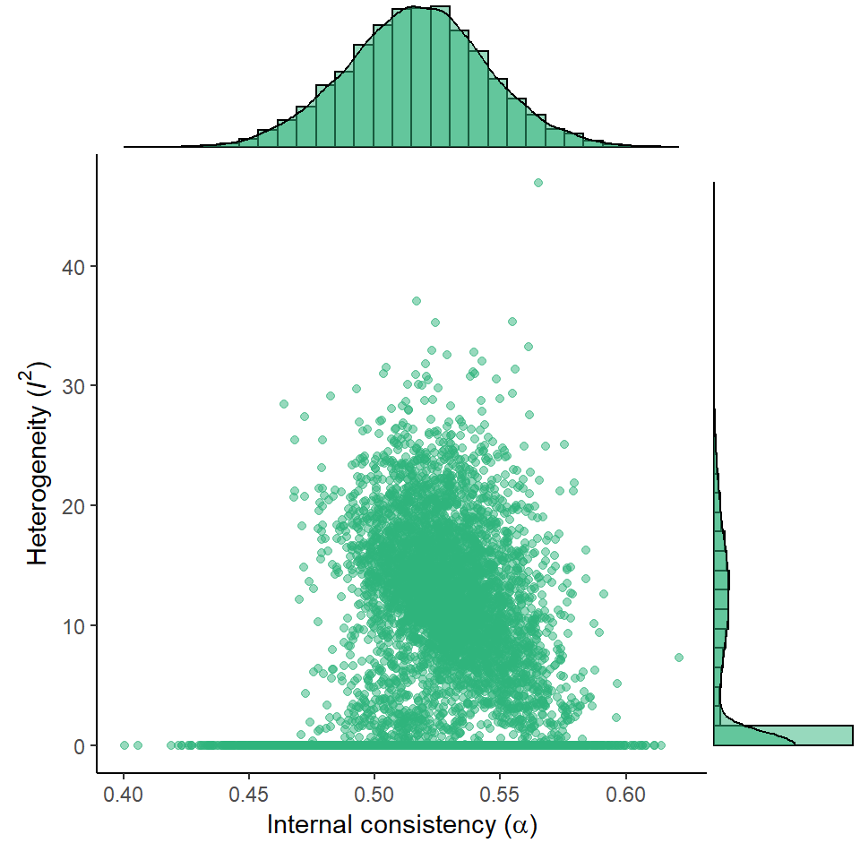

```r
if(!file.exists("models/fit_gosh_ic_sensitivity.rds")){

  fit_gosh_ic_sensitivity <- gosh(fit_internal_consistency_permuted_estimates_sensitivity,
                                  subsets = 10000,
                                  parallel = "multicore",  # change to "snow" on windows
                                  ncpus = parallel::detectCores())

  write_rds(fit_gosh_ic_sensitivity, "models/fit_gosh_ic_sensitivity.rds")

} else {

  fit_gosh_ic_sensitivity <- read_rds("models/fit_gosh_ic_sensitivity.rds")

}

data_for_plotting_ic_sensitivity <-
  as.tibble(fit_gosh_ic_sensitivity$res) %>%
  mutate(Type = "Other IRAPs",
         alpha = transf.iabt(estimate)) %>%
  # randomize rows to improve plotting
  sample_frac(size = 1)

p3 <-
  ggplot(data_for_plotting_ic_sensitivity, aes(alpha, I2, color = Type)) +
  geom_point(alpha = 0.5) +
  scale_color_viridis_d(begin = 0.35, end = 0.65, direction = -1) +
  theme_classic() +
  xlab(expression("Internal consistency (" * alpha * ")")) +
  ylab(expression("Heterogeneity (" * italic("I")^"2" * ")")) +
  theme(legend.position = c(0.2, 0.85)) +
  theme(legend.position = "none")

plot_gosh_ic_sensitivity <-
  ggMarginal(p3,
             type = "densigram",
             size = 4,
             margins = "both",
             groupFill = TRUE)

plot_gosh_ic_sensitivity
```

```r
write_rds(plot_gosh_ic_sensitivity, "models/plot_gosh_ic_sensitivity.rds")

data_for_plotting_ic_sensitivity %>%
  summarize(alpha_median = median(alpha, na.rm = TRUE),
            alpha_ci_lower = quantile(alpha, 0.025, na.rm = TRUE),
            alpha_ci_upper = quantile(alpha, 0.975, na.rm = TRUE),
            I2_median = median(I2, na.rm = TRUE),
            I2_ci_lower = quantile(I2, 0.025, na.rm = TRUE),
            I2_ci_upper = quantile(I2, 0.975, na.rm = TRUE),
            H2_median = median(H2, na.rm = TRUE),
            H2_ci_lower = quantile(H2, 0.025, na.rm = TRUE),
            H2_ci_upper = quantile(H2, 0.975, na.rm = TRUE)) %>%
  round_df(2) %>%
  kable() %>%
  kable_styling(bootstrap_options = c("striped", "hover", "condensed"), full_width = FALSE)
```

| alpha_median | alpha_ci_lower | alpha_ci_upper | I2_median | I2_ci_lower | I2_ci_upper | H2_median | H2_ci_lower | H2_ci_upper |
| --- | --- | --- | --- | --- | --- | --- | --- | --- |
| 0.52 | 0.46 | 0.57 | 0.38 | 0 | 22.54 | 1 | 1 | 1.29 |

# Test-retest reliability

## Pearson’s r correlations

with r-to-z transformations.

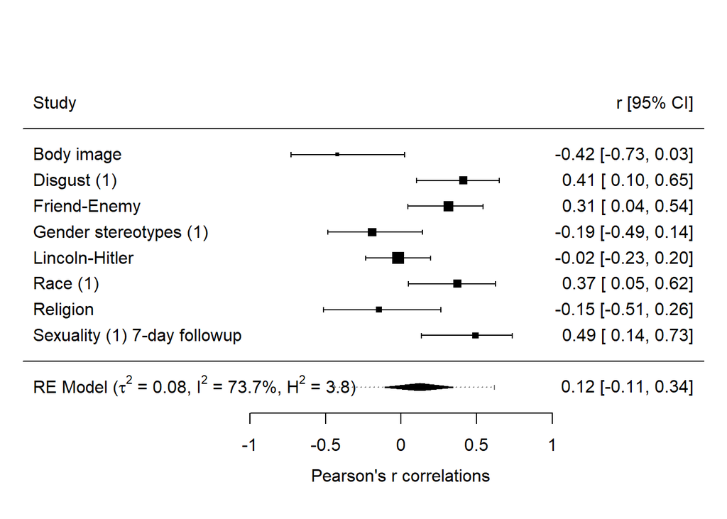

```r
fit_test_retest_r <- data_D_scores_test_retest_r %>%
  mutate(domain = ifelse(domain == "Sexuality (1)", "Sexuality (1) 7-day followup", domain)) %>%
  rma(yi   = yi,
      vi   = vi,
      data = .,
      slab = domain)

# make predictions
predictions_test_retest_r <-
  predict(fit_test_retest_r, digits = 5) %>%
  as.data.frame() %>%
  round_df(2)

# plot
metafor::forest(fit_test_retest_r,
                xlab = "Pearson's r correlations",
                transf = transf.ztor,
                addcred = TRUE,
                refline = FALSE,
                xlim = c(-2.5, 2),
                at = c(-1, -0.5, 0, 0.5, 1),
                mlab = add_heterogeneity_metrics_to_forest(fit_test_retest_r))
text(-2.5, 10, "Study", pos = 4)
text(2, 10, "r [95% CI]", pos = 2)
```

```r
# summarize results
meta_effect <-
  paste0("Meta analysis: k = ", fit_test_retest_r$k,
         ", r = ",  janitor::round_half_up(transf.ztor(predictions_test_retest_r$pred), 2),
         ", 95% CI [", janitor::round_half_up(transf.ztor(predictions_test_retest_r$ci.lb), 2), ", ",
         janitor::round_half_up(transf.ztor(predictions_test_retest_r$ci.ub), 2), "]",
         ", 95% CR [", janitor::round_half_up(transf.ztor(predictions_test_retest_r$pi.lb), 2), ", ",
         janitor::round_half_up(transf.ztor(predictions_test_retest_r$pi.ub), 2), "]")

meta_heterogeneity <-
  paste0("Heterogeneity tests: Q(df = ", fit_test_retest_r$k - 1, ") = ", janitor::round_half_up(fit_test_retest_r$QE, 2),
         ", p ", ifelse(fit_test_retest_r$QEp < 0.0001, "< .0001", paste0("= ", as.character(janitor::round_half_up(fit_test_retest_r$QEp, 4)))),
         ", tau^2 = ", janitor::round_half_up(fit_test_retest_r$tau2, 2),
         ", I^2 = ",   janitor::round_half_up(fit_test_retest_r$I2, 2),
         "%, H^2 = ",   janitor::round_half_up(fit_test_retest_r$H2, 2))

# write to disk for pdf plots
write_rds(fit_test_retest_r, "models/fit_test_retest_r.rds")
```

Meta effect: Meta analysis: k = 8, r = 0.12, 95% CI [-0.11, 0.34], 95% CR [-0.45, 0.62].

Heterogeneity: Heterogeneity tests: Q(df = 7) = 24.04, p = 0.0011, tau^2 = 0.08, I^2 = 73.71%, H^2 = 3.8.

## Intraclass Correlations

“It has been argued that test-retest reliability should reflect absolute agreement, rather than consistency, between measurements (Koo & Li, 2016). For example, a perfect correlation between scores at two time points may occur also when there is a systematic difference between time points (i.e. a difference that is about equal for all participants).” (Parsons, Kruijt, & Fox, 2019). Absolute agreement therefore also takes within-participant changes into account in its denominator, where consistency does not.

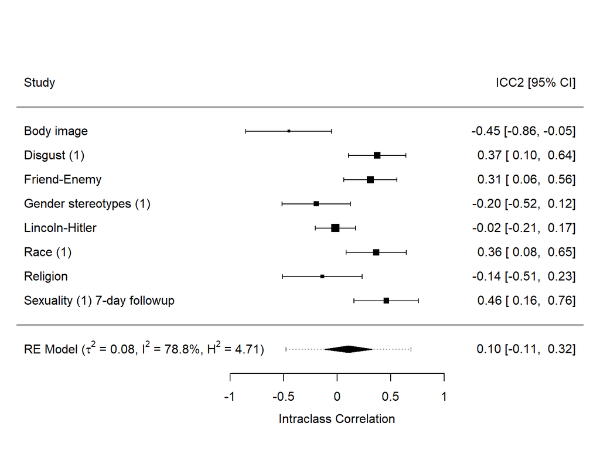

```r
# fit random Effects model
fit_test_retest_icc <- data_D_scores_test_retest_icc %>%
  mutate(domain = ifelse(domain == "Sexuality (1)", "Sexuality (1) 7-day followup", domain)) %>%
  rma(yi   = ICC,
      sei  = se,
      data = .,
      slab = domain)

# make predictions
predictions_test_retest_icc <-
  predict(fit_test_retest_icc, digits = 5) %>%
  as.data.frame() %>%
  round_df(2)

# # plot
# metafor::forest(fit_test_retest_icc,
#                 xlab = "ICC2",
#                 addcred = TRUE,
#                 refline = FALSE,
#                 xlim = c(-1.5, 1.7),
#                 at = c(-0.5, -0.25, 0, 0.25, 0.5, 0.75, 1),
#                 mlab = add_heterogeneity_metrics_to_forest(fit_test_retest_icc))
# text(-1.5, 10, "Study", pos = 4)
# text(1.7, 10, "ICC2 [95% CI]", pos = 2)

# plot
metafor::forest(fit_test_retest_icc,
                xlab = "Intraclass Correlation",
                addcred = TRUE,
                refline = FALSE,
                xlim = c(-3, 2.3),
                #at = c(-1, -0.75, -0.5, -0.25, 0, 0.25, 0.5, 0.75, 1),
                at = c(-1, -0.5, 0, 0.5, 1),
                mlab = add_heterogeneity_metrics_to_forest(fit_test_retest_icc))
text(-3, 10, "Study", pos = 4)
text(2.3, 10, "ICC2 [95% CI]", pos = 2)
```

```r
# summarize results
meta_effect <-
  paste0("Meta analysis: k = ", fit_test_retest_icc$k,
         ", ICC2 = ",  janitor::round_half_up(predictions_test_retest_icc$pred, 2),
         ", 95% CI [", janitor::round_half_up(predictions_test_retest_icc$ci.lb, 2), ", ",
         janitor::round_half_up(predictions_test_retest_icc$ci.ub, 2), "]",
         ", 95% CR [", janitor::round_half_up(predictions_test_retest_icc$pi.lb, 2), ", ",
         janitor::round_half_up(predictions_test_retest_icc$pi.ub, 2), "]")

meta_heterogeneity <-
  paste0("Heterogeneity tests: Q(df = ", fit_test_retest_icc$k - 1, ") = ", janitor::round_half_up(fit_test_retest_icc$QE, 2),
         ", p ", ifelse(fit_test_retest_icc$QEp < 0.0001, "< .0001", paste0("= ", as.character(janitor::round_half_up(fit_test_retest_icc$QEp, 4)))),
         ", tau^2 = ", janitor::round_half_up(fit_test_retest_icc$tau2, 2),
         ", I^2 = ",   janitor::round_half_up(fit_test_retest_icc$I2, 2),
         "%, H^2 = ",   janitor::round_half_up(fit_test_retest_icc$H2, 2))

# write to disk for pdf plots
write_rds(fit_test_retest_icc, "models/fit_test_retest_icc.rds")
```

Meta effect: Meta analysis: k = 8, ICC2 = 0.1, 95% CI [-0.11, 0.32], 95% CR [-0.48, 0.69].

Heterogeneity: Heterogeneity tests: Q(df = 7) = 28.84, p = 2e-04, tau^2 = 0.08, I^2 = 78.75%, H^2 = 4.71.

### GOSH

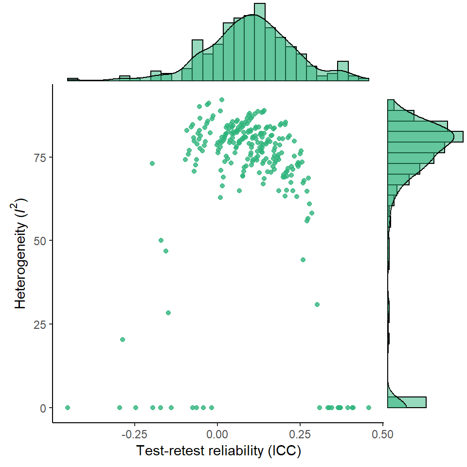

```r
if(!file.exists("models/fit_gosh_trt.rds")){

  fit_gosh_trt <- gosh(fit_test_retest_icc,
                       parallel = "multicore", # change to "snow" on windows
                       ncpus = parallel::detectCores())

  write_rds(fit_gosh_trt, "models/fit_gosh_trt.rds")

} else {

  fit_gosh_trt <- read_rds("models/fit_gosh_trt.rds")

}

data_for_plotting_trt <-
  as.tibble(fit_gosh_trt$res) %>%
  mutate(Type = "Other IRAPs",
         ICC = estimate) %>%
  # randomize rows to improve plotting
  sample_frac(size = 1)

p2 <-
  ggplot(data_for_plotting_trt, aes(ICC, I2, color = Type)) +
  geom_point(alpha = 0.8) +
  scale_color_viridis_d(begin = 0.35, end = 0.65, direction = -1) +
  theme_classic() +
  xlab("Test-retest reliability (ICC)") +
  ylab(expression("Heterogeneity (" * italic("I")^"2" * ")")) +
  theme(legend.position = "none")

plot_gosh_trt <-
  ggMarginal(p2,
             type = "densigram",
             size = 4,
             margins = "both",
             groupFill = TRUE)

plot_gosh_trt
```

```r
write_rds(plot_gosh_trt, "models/plot_gosh_trt.rds")

data_for_plotting_trt %>%
  summarize(ICC_median = median(ICC, na.rm = TRUE),
            ICC_ci_lower = quantile(ICC, 0.025, na.rm = TRUE),
            ICC_ci_upper = quantile(ICC, 0.975, na.rm = TRUE),
            I2_median = median(I2, na.rm = TRUE),
            I2_ci_lower = quantile(I2, 0.025, na.rm = TRUE),
            I2_ci_upper = quantile(I2, 0.975, na.rm = TRUE),
            H2_median = median(H2, na.rm = TRUE),
            H2_ci_lower = quantile(H2, 0.025, na.rm = TRUE),
            H2_ci_upper = quantile(H2, 0.975, na.rm = TRUE)) %>%
  round_df(2) %>%
  kable() %>%
  kable_styling(bootstrap_options = c("striped", "hover", "condensed"), full_width = FALSE)
```

| ICC_median | ICC_ci_lower | ICC_ci_upper | I2_median | I2_ci_lower | I2_ci_upper | H2_median | H2_ci_lower | H2_ci_upper |
| --- | --- | --- | --- | --- | --- | --- | --- | --- |
| 0.1 | -0.17 | 0.37 | 77.92 | 0 | 88.62 | 4.53 | 1 | 8.79 |

# Power implications

Maximum observed correlation of two measures is a function of their true correlation and the reliability (i.e., self-correlation) of each measure.

## Internal Consistency

```r
observed_r <- function(true_r, reliability_a, reliability_b) {
  janitor::round_half_up(true_r * sqrt(reliability_a*reliability_b), 2)
}

max_cor <- observed_r(true_r = 1.0,
                      reliability_a = transf.iabt(predictions_permutations_sensitivity$pred),
                      reliability_b = 1.0)

medium_cor <- observed_r(true_r = 0.5,
                         reliability_a = transf.iabt(predictions_permutations_sensitivity$pred),
                         reliability_b = 1.0)
```

Given this meta estimate of reliability, assuming that the internal consistency of an external variable is perfect (1.0), the maximum correlation between the IRAP and that external variable (i.e., when true correlation is 1.0) is 0.72. For a true correlation of medium size (r = .5), the observed correlation would be 0.36.

## Test-retest

```r
max_cor <- observed_r(true_r = 1.0,
                      reliability_a = predictions_test_retest_icc$pred,
                      reliability_b = 1.0)

medium_cor <- observed_r(true_r = 0.5,
                         reliability_a = predictions_test_retest_icc$pred,
                         reliability_b = 1.0)
```

Given this meta estimate of reliability, assuming that the internal consistency of an external variable is perfect (1.0), the maximum correlation between the IRAP and that external variable (i.e., when true correlation is 1.0) is 0.32. For a true correlation of medium size (r = .5), the observed correlation would be 0.16.

# Potential ways to improve reliability

## Lengthening the task

Although there was some variation in test lengths, this was in a very small range of domains that also appeared to be particularly stable ones. It’s not meaningful to do moderation meta analysis on the existing data.

### Internal Consistency

The [Spearman-Brown prediction formula](https://en.wikipedia.org/wiki/Spearman%E2%80%93Brown_prediction_formula#Forecasting_test_length) can be rearranged to make prediction about how the length of the test would need to change to meet a goal reliability:

$\rho_{xx'}^*=\frac {n\rho_{xx'}}{1+(n-1)\rho_{xx'}}$

where $\rho_{xx'}^*$ refers to the goal reliability, $\rho_{xx'}$ refers to the current reliability, and $n$ refers to the test length multiplier.

```r
current_ic <- transf.iabt(predictions_permutations_sensitivity$pred)

goal_ic <- 0.70
ic_length_increase_.70 <- janitor::round_half_up((goal_ic*(1 - current_ic)) / (current_ic*(1 - goal_ic)), 1)

goal_ic <- 0.80
ic_length_increase_.80 <- janitor::round_half_up((goal_ic*(1 - current_ic)) / (current_ic*(1 - goal_ic)), 1)

goal_ic <- 0.90
ic_length_increase_.90 <- janitor::round_half_up((goal_ic*(1 - current_ic)) / (current_ic*(1 - goal_ic)), 1)
```

Using $a$ = 0.52, the IRAP would have to be 2.2 times longer for it to have an internal consistency of >=.70, 3.7 times longer for it to have an internal consistency of >=.80, or 8.4 times longer for it to have an internal consistency of >=.90.

### Test-retest

The [Spearman-Brown prediction formula](https://en.wikipedia.org/wiki/Spearman%E2%80%93Brown_prediction_formula#Forecasting_test_length) can be rearranged to make prediction about how the length of the test would need to change to meet a goal reliability:

${\rho }_{xx'}^{*}={\frac {n{\rho }_{xx'}}{1+(n-1){\rho }_{xx'}}}$

where ${\rho }_{xx'}^{*}$ refers to the goal reliability, ${\rho }_{xx'}$ refers to the current reliability, and ${n}$ refers to the test length multiplier.

```r
current_test_retest <- predictions_test_retest_icc$pred

goal_test_retest <- 0.70
trt_length_increase_.70 <- janitor::round_half_up((goal_test_retest*(1 - current_test_retest)) / (current_test_retest*(1 - goal_test_retest)), 1)

goal_test_retest <- 0.80
trt_length_increase_.80 <- janitor::round_half_up((goal_test_retest*(1 - current_test_retest)) / (current_test_retest*(1 - goal_test_retest)), 1)

goal_test_retest <- 0.90
trt_length_increase_.90 <- janitor::round_half_up((goal_test_retest*(1 - current_test_retest)) / (current_test_retest*(1 - goal_test_retest)), 1)
```

Using the absolute agreement estimate of 0.1, the IRAP would have to be 21 times longer for it to have a test-retest of >=.70, 36 times longer for it to have a test-retest of >=.80, or 81 times longer for it to have a test-retest of >=.90.

## Alternative scoring algorithm: A scores

Internal consistency using permutation approach sensitivity analysis, comparing D scoring and A scoring. Multilevel moderator meta analyses, acknowledging non-independence between scores produced for each domain, and moderator by scoring type.

```r
fit_internal_consistency_D_vs_A_scores <-
  bind_rows(data_A_scores_internal_consistency_permuted_estimates %>%
              filter(!str_detect(domain, "Sexuality")) %>%
              mutate(scoring = "A"),
            data_D_scores_internal_consistency_permuted_estimates %>%
              filter(!str_detect(domain, "Sexuality")) %>%
              mutate(scoring = "D")) %>%
  mutate(scoring = fct_relevel(scoring, "D", "A")) %>%
  rma.mv(yi     = yi,
         V      = vi,
         random = ~ 1 | domain,
         mods   = ~ scoring,
         data   = .,
         slab   = domain)

fit_internal_consistency_D_vs_A_scores
```

```
##
## Multivariate Meta-Analysis Model (k = 78; method: REML)
##
## Variance Components:
##
##             estim    sqrt  nlvls  fixed  factor
## sigma^2    0.0439  0.2096     39     no  domain
##
## Test for Residual Heterogeneity:
## QE(df = 76) = 73.7813, p-val = 0.5507
##
## Test of Moderators (coefficient 2):
## QM(df = 1) = 0.7290, p-val = 0.3932
##
## Model Results:
##
##           estimate      se     zval    pval    ci.lb   ci.ub
## intrcpt     0.7358  0.0637  11.5520  <.0001   0.6110  0.8607  ***
## scoringA    0.0611  0.0716   0.8538  0.3932  -0.0792  0.2014
##
## ---
## Signif. codes:  0 '***' 0.001 '**' 0.01 '*' 0.05 '.' 0.1 ' ' 1
```

```r
tibble(response_options = c("D", "A"),
       alpha = c(fit_internal_consistency_D_vs_A_scores$b[1],
                 fit_internal_consistency_D_vs_A_scores$b[1] +
                   fit_internal_consistency_D_vs_A_scores$b[2]),
       ci_lower = c(fit_internal_consistency_D_vs_A_scores$ci.lb[1],
                    fit_internal_consistency_D_vs_A_scores$b[1] +
                      fit_internal_consistency_D_vs_A_scores$ci.lb[2]),
       ci_upper = c(fit_internal_consistency_D_vs_A_scores$ci.ub[1],
                    fit_internal_consistency_D_vs_A_scores$b[1] +
                      fit_internal_consistency_D_vs_A_scores$ci.ub[2])) %>%
  mutate_if(is.numeric, transf.iabt) %>%
  mutate_if(is.numeric, round, digits = 2) %>%
  kable() %>%
  kable_styling(bootstrap_options = c("striped", "hover", "condensed"), full_width = FALSE)
```

| response_options | alpha | ci_lower | ci_upper |
| --- | --- | --- | --- |
| D | 0.52 | 0.46 | 0.58 |
| A | 0.55 | 0.48 | 0.61 |

## Use only one block order

Internal consistency using permutation approach sensitivity analysis, multilevel moderator meta analysis between block orders for the domains that have both.

```r
fit_internal_consistency_block_order <-
  data_D_scores_internal_consistency_permuted_estimates_by_block_order %>%
  filter(!str_detect(domain, "Sexuality")) %>%
  rma.mv(yi     = yi,
         V      = vi,
         mods   = ~ block_order,
         random = ~ 1 | domain,
         data   = .,
         slab   = paste(domain, block_order))

fit_internal_consistency_block_order
```

```
##
## Multivariate Meta-Analysis Model (k = 48; method: REML)
##
## Variance Components:
##
##             estim    sqrt  nlvls  fixed  factor
## sigma^2    0.0112  0.1058     24     no  domain
##
## Test for Residual Heterogeneity:
## QE(df = 46) = 27.1896, p-val = 0.9877
##
## Test of Moderators (coefficient 2):
## QM(df = 1) = 1.9150, p-val = 0.1664
##
## Model Results:
##
##                                estimate      se    zval    pval    ci.lb
## intrcpt                          0.6078  0.0949  6.4078  <.0001   0.4219
## block_orderinconsistent first    0.1853  0.1339  1.3838  0.1664  -0.0771
##                                 ci.ub
## intrcpt                        0.7937  ***
## block_orderinconsistent first  0.4477
##
## ---
## Signif. codes:  0 '***' 0.001 '**' 0.01 '*' 0.05 '.' 0.1 ' ' 1
```

```r
tibble(block_order = c("con first", "incon first"),
       alpha = c(fit_internal_consistency_block_order$b[1],
                 fit_internal_consistency_block_order$b[1] +
                   fit_internal_consistency_block_order$b[2]),
       ci_lower = c(fit_internal_consistency_block_order$ci.lb[1],
                    fit_internal_consistency_block_order$b[1] +
                      fit_internal_consistency_block_order$ci.lb[2]),
       ci_upper = c(fit_internal_consistency_block_order$ci.ub[1],
                    fit_internal_consistency_block_order$b[1] +
                      fit_internal_consistency_block_order$ci.ub[2])) %>%
  mutate_if(is.numeric, transf.iabt) %>%
  mutate_if(is.numeric, round, digits = 2) %>%
  kable() %>%
  kable_styling(bootstrap_options = c("striped", "hover", "condensed"), full_width = FALSE)
```

| block_order | alpha | ci_lower | ci_upper |
| --- | --- | --- | --- |
| con first | 0.46 | 0.34 | 0.55 |
| incon first | 0.55 | 0.41 | 0.65 |

## Use only either fixed or moving response options

Internal consistency using permutation approach sensitivity analysis, moderator meta analysis between response option locations between domains.

```r
fit_internal_consistency_response_option_locations <-
  data_D_scores_internal_consistency_permuted_estimates %>%
  filter(!str_detect(domain, "Sexuality") &
           !is.na(response_option_locations)) %>%
  rma(yi   = yi,
      vi   = vi,
      mods = ~ response_option_locations,
      data = .,
      slab = paste(domain, response_option_locations))

fit_internal_consistency_response_option_locations
```

```
##
## Mixed-Effects Model (k = 39; tau^2 estimator: REML)
##
## tau^2 (estimated amount of residual heterogeneity):     0 (SE = 0.0191)
## tau (square root of estimated tau^2 value):             0
## I^2 (residual heterogeneity / unaccounted variability): 0.00%
## H^2 (unaccounted variability / sampling variability):   1.00
## R^2 (amount of heterogeneity accounted for):            100.00%
##
## Test for Residual Heterogeneity:
## QE(df = 37) = 21.8190, p-val = 0.9776
##
## Test of Moderators (coefficient 2):
## QM(df = 1) = 8.4618, p-val = 0.0036
##
## Model Results:
##
##                                  estimate      se     zval    pval    ci.lb
## intrcpt                            0.9254  0.0826  11.2009  <.0001   0.7635
## response_option_locationsMoving   -0.3040  0.1045  -2.9089  0.0036  -0.5089
##                                    ci.ub
## intrcpt                           1.0873  ***
## response_option_locationsMoving  -0.0992   **
##
## ---
## Signif. codes:  0 '***' 0.001 '**' 0.01 '*' 0.05 '.' 0.1 ' ' 1
```

```r
tibble(response_options = c("static", "moving"),
       alpha = c(fit_internal_consistency_response_option_locations$b[1],
                 fit_internal_consistency_response_option_locations$b[1] +
                   fit_internal_consistency_response_option_locations$b[2]),
       ci_lower = c(fit_internal_consistency_response_option_locations$ci.lb[1],
                    fit_internal_consistency_response_option_locations$b[1] +
                      fit_internal_consistency_response_option_locations$ci.lb[2]),
       ci_upper = c(fit_internal_consistency_response_option_locations$ci.ub[1],
                    fit_internal_consistency_response_option_locations$b[1] +
                      fit_internal_consistency_response_option_locations$ci.ub[2])) %>%
  mutate_if(is.numeric, transf.iabt) %>%
  mutate_if(is.numeric, round, digits = 2) %>%
  kable() %>%
  kable_styling(bootstrap_options = c("striped", "hover", "condensed"), full_width = FALSE)
```

| response_options | alpha | ci_lower | ci_upper |
| --- | --- | --- | --- |
| static | 0.60 | 0.53 | 0.66 |
| moving | 0.46 | 0.34 | 0.56 |

## Use stricter performance exclusion criteria

Internal consistency using permutation approach sensitivity analysis, moderator meta analysis between criteria.

- Typical criteria require accuracy >= 78% and median RT < 2000ms on both con and incon blocks. It has a roughly 10% exclusion rate.
- Stricter criteria require accuracy >= 78% and median RT < 2000ms on both con and incon blocks *and within each block*. It has a roughly 28% exclusion rate.

```r
fit_internal_consistency_performance_criteria <-
  bind_rows(data_D_scores_internal_consistency_permuted_estimates %>%
              filter(!str_detect(domain, "Sexuality")) %>%
              mutate(exclusions = "typical"),
            data_D_scores_internal_consistency_permuted_estimates_stricter %>%
              filter(!str_detect(domain, "Sexuality")) %>%
              mutate(exclusions = "stricter")) %>%
  mutate(exclusions = fct_relevel(exclusions, "typical", "stricter")) %>%
  filter(!str_detect(domain, "Sexuality") &
           !is.na(exclusions)) %>%
  rma.mv(yi   = yi,
         V    = vi,
         mods = ~ exclusions,
         random = ~ 1 | domain,
         data = .,
         slab = paste(domain, exclusions))

fit_internal_consistency_performance_criteria
```

```
##
## Multivariate Meta-Analysis Model (k = 71; method: REML)
##
## Variance Components:
##
##             estim    sqrt  nlvls  fixed  factor
## sigma^2    0.0349  0.1868     39     no  domain
##
## Test for Residual Heterogeneity:
## QE(df = 69) = 59.4941, p-val = 0.7859
##
## Test of Moderators (coefficient 2):
## QM(df = 1) = 0.5307, p-val = 0.4663
##
## Model Results:
##
##                     estimate      se     zval    pval    ci.lb   ci.ub
## intrcpt               0.7302  0.0617  11.8362  <.0001   0.6092  0.8511  ***
## exclusionsstricter   -0.0589  0.0809  -0.7285  0.4663  -0.2175  0.0996
##
## ---
## Signif. codes:  0 '***' 0.001 '**' 0.01 '*' 0.05 '.' 0.1 ' ' 1
```

```r
tibble(exclusions = c("typical", "stricter"),
       alpha = c(fit_internal_consistency_performance_criteria$b[1],
                 fit_internal_consistency_performance_criteria$b[1] +
                   fit_internal_consistency_performance_criteria$b[2]),
       ci_lower = c(fit_internal_consistency_performance_criteria$ci.lb[1],
                    fit_internal_consistency_performance_criteria$b[1] +
                      fit_internal_consistency_performance_criteria$ci.lb[2]),
       ci_upper = c(fit_internal_consistency_performance_criteria$ci.ub[1],
                    fit_internal_consistency_performance_criteria$b[1] +
                      fit_internal_consistency_performance_criteria$ci.ub[2])) %>%
  mutate_if(is.numeric, transf.iabt) %>%
  mutate_if(is.numeric, round, digits = 2) %>%
  kable() %>%
  kable_styling(bootstrap_options = c("striped", "hover", "condensed"), full_width = FALSE)
```

| exclusions | alpha | ci_lower | ci_upper |
| --- | --- | --- | --- |
| typical | 0.52 | 0.46 | 0.57 |
| stricter | 0.49 | 0.40 | 0.56 |